# R Notebook

## 3 Data visualisation

This chapter focusses on ggplot2, one of the core members of the tidyverse

| manufacturer | model | displ | year | cyl | trans | drv | cty | hwy | fl | class |
| --- | --- | --- | --- | --- | --- | --- | --- | --- | --- | --- |
| audi | a4 | 1.8 | 1999 | 4 | auto(l5) | f | 18 | 29 | p | compact |
| audi | a4 | 1.8 | 1999 | 4 | manual(m5) | f | 21 | 29 | p | compact |
| audi | a4 | 2.0 | 2008 | 4 | manual(m6) | f | 20 | 31 | p | compact |
| audi | a4 | 2.0 | 2008 | 4 | auto(av) | f | 21 | 30 | p | compact |
| audi | a4 | 2.8 | 1999 | 6 | auto(l5) | f | 16 | 26 | p | compact |
| audi | a4 | 2.8 | 1999 | 6 | manual(m5) | f | 18 | 26 | p | compact |
| audi | a4 | 3.1 | 2008 | 6 | auto(av) | f | 18 | 27 | p | compact |
| audi | a4 quattro | 1.8 | 1999 | 4 | manual(m5) | 4 | 18 | 26 | p | compact |
| audi | a4 quattro | 1.8 | 1999 | 4 | auto(l5) | 4 | 16 | 25 | p | compact |
| audi | a4 quattro | 2.0 | 2008 | 4 | manual(m6) | 4 | 20 | 28 | p | compact |

[output cut: 224 more lines]

```r
names(mpg)
```

```
 [1] "manufacturer" "model"        "displ"        "year"         "cyl"
 [6] "trans"        "drv"          "cty"          "hwy"          "fl"
[11] "class"
```

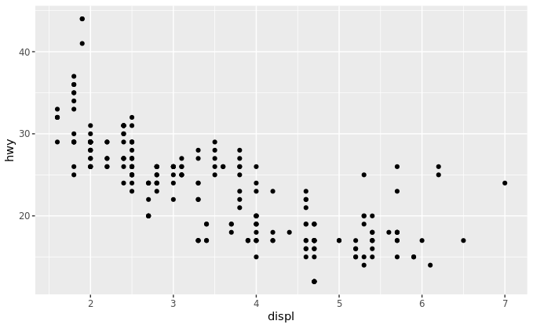

You only need to install a package once, but you need to reload it every time you start a new session.

If we need to be explicit about where a function (or dataset) comes from, we’ll use the special form package::function(). For example, ggplot2::ggplot() tells you explicitly that we’re using the ggplot() function from the ggplot2 package.

## 3.2.3 A graphing template

turn code into a reusable template for graphs with ggplot2. To make a graph, replace the bracketed sections in the code below with a dataset, a geom function, or a collection of mappings.

ggplot(data = ) + (mapping = aes())

## 3.2.4 Exercises

Run ggplot(data = mpg). What do you see? # nothing! empty graph

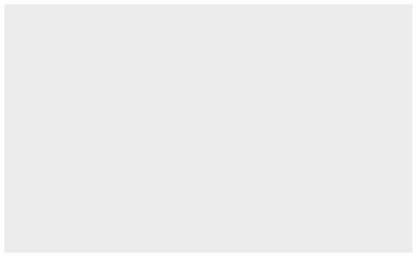

How many rows are in mpg? How many columns? #234 rows & 11

```r
length(mpg)
```

```
[1] 11
```

What does the drv variable describe? Read the help for ?mpg to find out.

drv f = front-wheel drive, r = rear wheel drive, 4 = 4wd Make a scatterplot of hwy vs cyl.

What happens if you make a scatterplot of class vs drv? Why is the plot not useful?

thet are both non numeric data

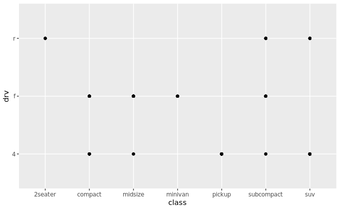

You can add a third variable, like class, to a two dimensional scatterplot by mapping it to an aesthetic. An aesthetic is a visual property of the objects in your plot.

```r
#ggplot(data = mpg) +
 # geom_point(mapping = aes(x = displ, y = hwy))
ggplot(data = mpg) +
  geom_point(mapping = aes(x = displ, y = hwy, color= class)) # add 'color= class' to get color and key

#use asign ment in code
f <- ggplot(data = mpg)
f+geom_point(mapping = aes(x = displ, y = hwy, color= class))#aes =astetics color, shape, size mus t go in astetics
#f+geom_point(mapping = aes(x = displ, y = hwy, color= class, size=class))#add size dosent look good
#f+geom_point(mapping = aes(x = displ, y = hwy, shape= class))#add shape dosent look good
#f+geom_point(mapping = aes(x = displ, y = hwy, shape= class,size=class,color= class))# add multiple  customizations
```

[output not shown]

mapped class to the color aesthetic, but we could have mapped class to the size aesthetic in the same way. In this case, the exact size of each point would reveal its class affiliation. We get a warning here, because mapping an unordered variable (class) to an ordered aesthetic (size) is not a good idea.

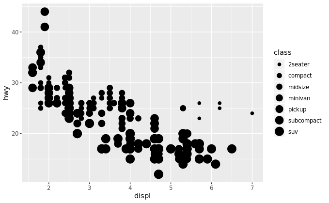

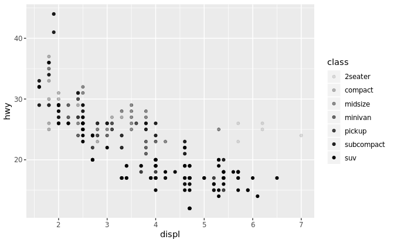

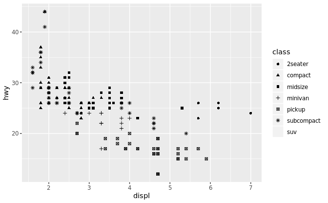

[figure not shown]

What’s gone wrong with this code? Why are the points not blue?

The color is in side the aes

```r
ggplot(data = mpg) +
  geom_point(mapping = aes(x = displ, y = hwy, color = "blue"))
```

[output not shown]

To facet your plot by a single variable, use facet_wrap()

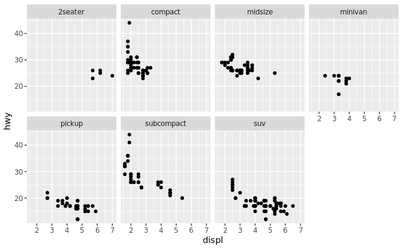

3.5.1 Exercises What happens if you facet on a continuous variable?

What do the empty cells in plot with facet_grid(drv ~ cyl) mean? How do they relate to this plot?

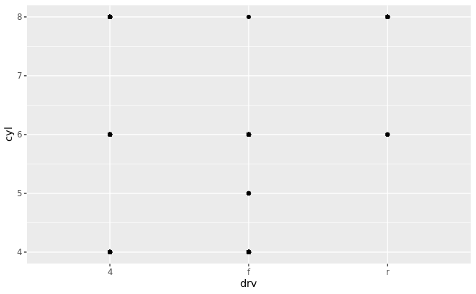

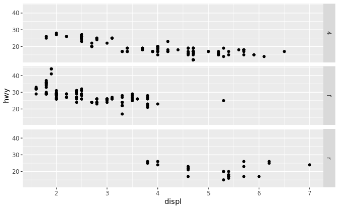

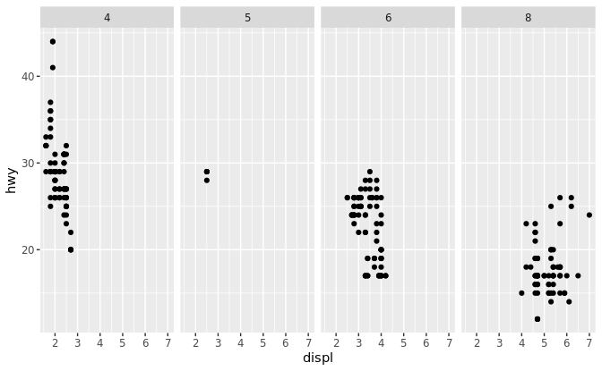

## 3.6 Geometric objects

How are these two plots similar? Both plots contain the same x variable, the same y variable, and both describe the same data

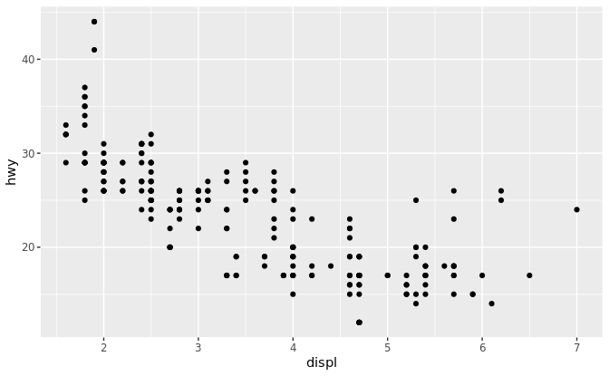

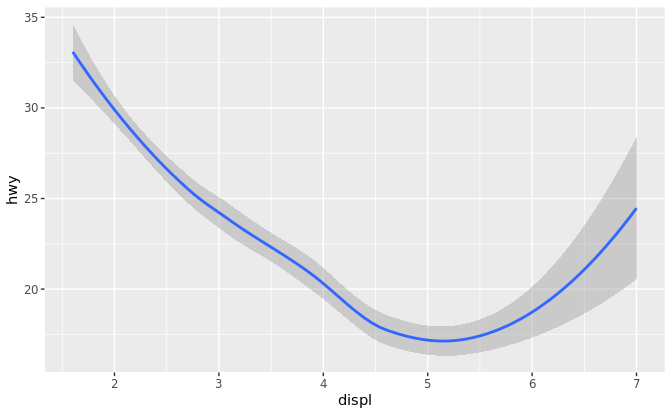

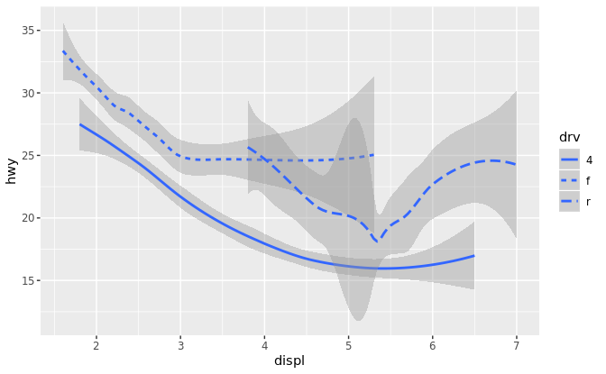

| carat | cut | color | clarity | depth | table | price | x | y | z |
| --- | --- | --- | --- | --- | --- | --- | --- | --- | --- |
| 0.23 | Ideal | E | SI2 | 61.5 | 55.0 | 326 | 3.95 | 3.98 | 2.43 |
| 0.21 | Premium | E | SI1 | 59.8 | 61.0 | 326 | 3.89 | 3.84 | 2.31 |
| 0.23 | Good | E | VS1 | 56.9 | 65.0 | 327 | 4.05 | 4.07 | 2.31 |
| 0.29 | Premium | I | VS2 | 62.4 | 58.0 | 334 | 4.20 | 4.23 | 2.63 |
| 0.31 | Good | J | SI2 | 63.3 | 58.0 | 335 | 4.34 | 4.35 | 2.75 |
| 0.24 | Very Good | J | VVS2 | 62.8 | 57.0 | 336 | 3.94 | 3.96 | 2.48 |
| 0.24 | Very Good | I | VVS1 | 62.3 | 57.0 | 336 | 3.95 | 3.98 | 2.47 |
| 0.26 | Very Good | H | SI1 | 61.9 | 55.0 | 337 | 4.07 | 4.11 | 2.53 |
| 0.22 | Fair | E | VS2 | 65.1 | 61.0 | 337 | 3.87 | 3.78 | 2.49 |
| 0.23 | Very Good | H | VS1 | 59.4 | 61.0 | 338 | 4.00 | 4.05 | 2.39 |

[output cut: 990 more lines]

```r
library(viridisLite)
```

[output not shown]

```r
ggplot(data = diamonds) +
  geom_bar(mapping = aes(x = cut, colour = cut))
```

[output not shown]

```r
ggplot(data = diamonds) +
  geom_bar(mapping = aes(x = cut, fill = cut))
```

[output not shown]

```r
ggplot(data = diamonds) +
  geom_bar(mapping = aes(x = cut, fill = clarity))
```

[output not shown]